# Reproducible Research Assignment 1

Dwight Kruger

Monday, August 11, 2014

The data for this assignment was downloaded from the course web site:

Dataset: Activity monitoring data [52K]. The variables included in this dataset are:

- steps: Number of steps taking in a 5-minute interval (missing values are coded as NA)

*date: The date on which the measurement was taken in YYYY-MM-DD format

- interval: Identifier for the 5-minute interval in which measurement was taken

The dataset is stored in a comma-separated-value (CSV) file and there are a total of 17,568 observations in this dataset.

Q1: What is mean total number of steps taken per day?

For this part of the assignment, you can ignore the missing values in the dataset.

- Make a histogram of the total number of steps taken each day
- Calculate and report the mean and median total number of steps taken per day

```r
    # Unzip the data file stored in the project.
    sourceFile.zip <- "./activity.zip"
    unzip(sourceFile.zip, overwrite = TRUE, exdir = ".")

    # Read the datafile into a data frame, with the column types as numeric, date, numeric
    setClass('myDate')
    setAs("character","myDate", function(from) as.Date(from, format="%Y-%m-%d") )
    colClasses = c("numeric", "myDate", "numeric")
    activity = read.csv("./activity.csv", stringsAsFactors = FALSE, colClasses = colClasses)
```

```r
    library(data.table)
```

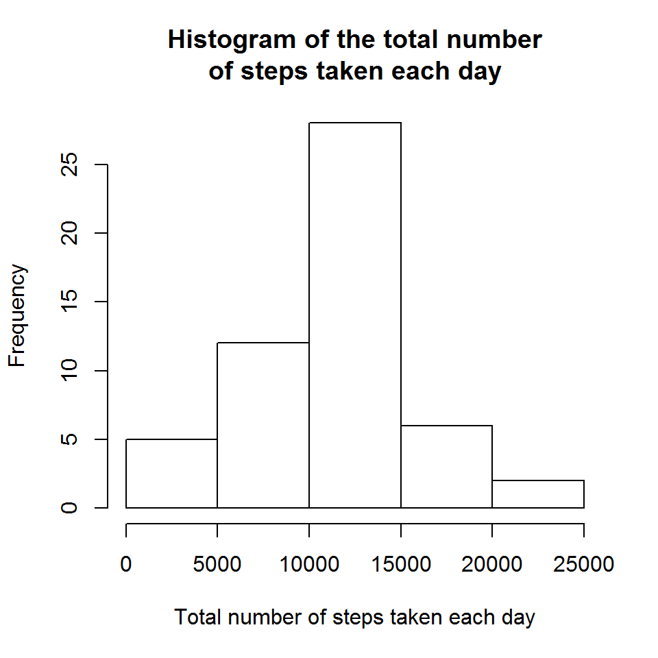

```r
    table = data.table(activity)
    table = table[complete.cases(table), ]
    activityStepsByDate = table[,sum(steps), by=date]
    setnames(activityStepsByDate, c("date", "V1"), c("Date", "TotalSteps"))

    meanStepsPerDay = mean(activityStepsByDate$TotalSteps, na.rm = TRUE)
    medianStepsPerDay = median(activityStepsByDate$TotalSteps, na.rm = TRUE)

    hist(activityStepsByDate$TotalSteps,
         xlab="Total number of steps taken each day",
         main="Histogram of the total number\nof steps taken each day")
```

```r
    print.noquote(paste("Mean steps per day = ", meanStepsPerDay, sep=""))
```

[1] Mean steps per day = 10766.1886792453

```r
    print.noquote(paste("Median steps per day = ", medianStepsPerDay, sep=""))
```

[1] Median steps per day = 10765

Q2: What is the average daily activity pattern?

```
Make a time series plot (i.e. type = "l") of the 5-minute interval (x-axis) and
the average number of steps taken, averaged across all days (y-axis).
```

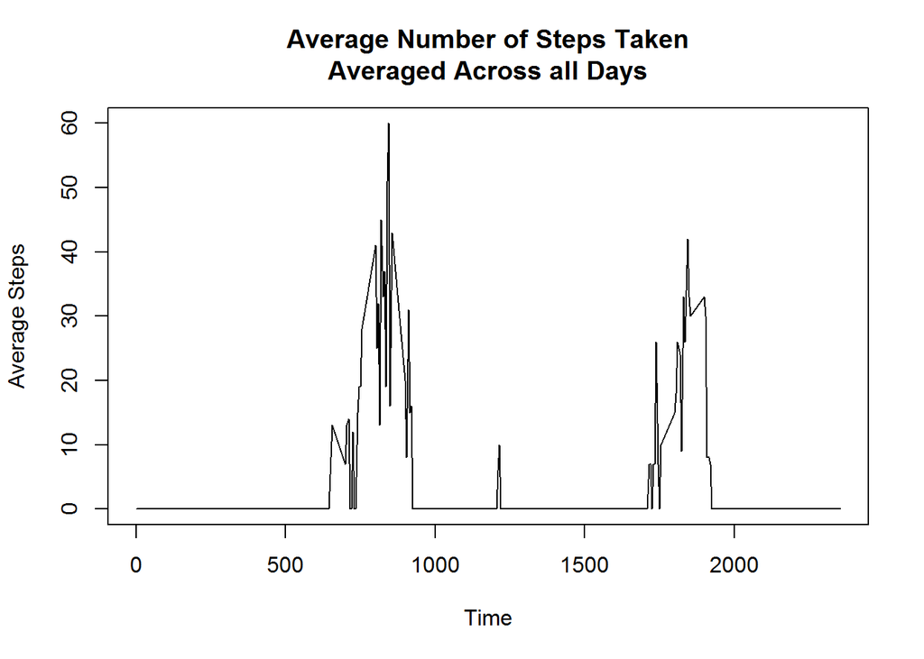

```
Which 5-minute interval, on average across all the days in the dataset, contains the
maximum number of steps?
```

```r
    activityByTime <- table[, median(steps), by=interval]
    setnames(activityByTime, c("interval", "V1"), c("Interval", "AvgSteps"))
    plot(x = activityByTime$Interval,
         y=activityByTime$AvgSteps,
         type = "l",
         xlab="Time",
         ylab="Average Steps",
         main="Average Number of Steps Taken\nAveraged Across all Days")
```

```r
    maxInterval <- activityByTime$Interval[which.max(activityByTime$AvgSteps)]

    print.noquote(paste("The 5-minute interval with the max number of steps is interval ", maxInterval, sep=""))
```

```
## [1] The 5-minute interval with the max number of steps is interval 845
```

Q3: Calculate and report the total number of missing values in the dataset (i.e. the total number of rows with NAs)

```r
    missingValues= is.na(activity$steps)
    totalNumberMissingValues <- sum(missingValues)

    print.noquote(paste("Total numer of missing values = ", totalNumberMissingValues, sep=""))
```

```
## [1] Total numer of missing values = 2304
```

Create a new dataset that is equal to the original dataset but with the missing data filled in

```r
    # Replace the missing values with the mean for that 5-minute interval
    activityPlusMissingData <- activity
    for (i in 1:dim(activityPlusMissingData)[1])
    {
        if (missingValues[i])
        {
            activityPlusMissingData$steps[i] = activityByTime[Interval==activityPlusMissingData[i,]$interval, ]$AvgSteps
        }
    }

    table2 = data.table(activityPlusMissingData)
    table2 = table2[complete.cases(table2), ]
    activityStepsByDateWithMissingData = table2[,sum(steps), by=date]
    setnames(activityStepsByDateWithMissingData, c("date", "V1"), c("Date", "TotalSteps"))
```

Make a histogram of the total number of steps taken each day and Calculate and report the mean and median total number of steps taken per day. Do these values differ from the estimates from the first part of the assignment? What is the impact of imputing missing data on the estimates of the total daily number of steps?

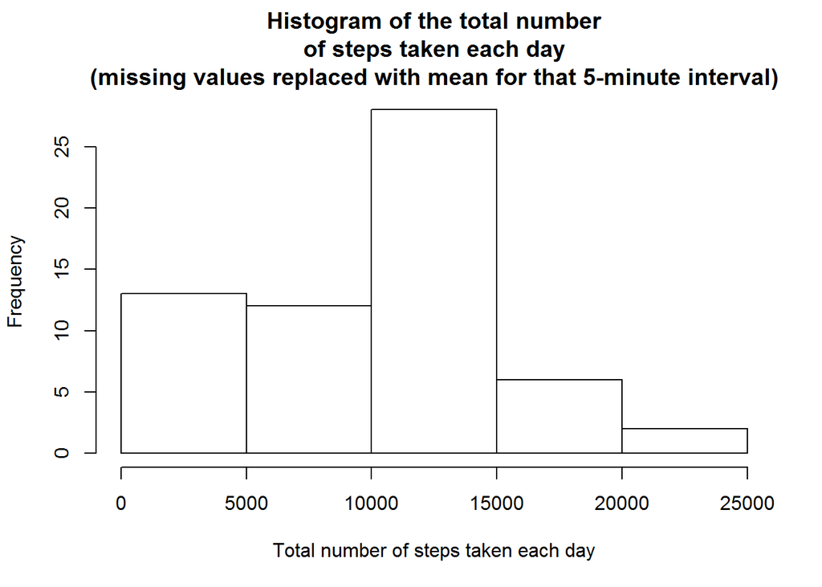

```r
    hist(activityStepsByDateWithMissingData$TotalSteps,
         xlab="Total number of steps taken each day",
         main="Histogram of the total number\nof steps taken each day\n(missing values replaced with mean for that 5-minute interval)")
```

```r
    meanStepsPerDayWithMissingData = mean(activityStepsByDateWithMissingData$TotalSteps, na.rm = TRUE)
    medianStepsPerDayWithMissingData = median(activityStepsByDateWithMissingData$TotalSteps, na.rm = TRUE)

    totalNumberOfSteps = sum(activity$steps, na.rm = TRUE)
    totalNumberOfStepsWithMissingData = sum(activityPlusMissingData$steps, na.rm = TRUE)

    if ((meanStepsPerDayWithMissingData == meanStepsPerDay) &
        (medianStepsPerDayWithMissingData == medianStepsPerDay))
    {
       print.noquote("The mean and median number of steps do NOT differ when missing values are replaced")
    } else
    {
        print.noquote("The mean and median number of steps DO differ when missing values are replaced")
    }
```

[1] The mean and median number of steps DO differ when missing values are replaced

```r
    if (totalNumberOfStepsWithMissingData == totalNumberOfSteps)
    {
       print.noquote("The total number of steps do NOT differ when missing values are replaced")
    } else
    {
        print.noquote("The total number of steps DO differ when missing values are replaced")
    }
```

[1] The total number of steps DO differ when missing values are replaced

Are there differences in activity patterns between weekdays and weekends?

Create a new factor variable in the dataset with two levels - “weekday” and “weekend” indicating whether a given date is a weekday or weekend day.

```r
    weekendActivity = grepl("(Sun|Sat)", weekdays(activity$date, abbreviate=TRUE))
    activity$IsWeekend <- factor(weekendActivity, levels=c(TRUE, FALSE), labels=c("Weekend", "Weekday"))
```

Make a panel plot containing a time series plot (i.e. type = “l”) of the 5-minute interval (x-axis) and the average number of steps taken, averaged across all weekday days or weekend days (y-axis).

[figure not shown]

```r
    weekendActivity = grepl("(Sun|Sat)", weekdays(activityPlusMissingData$date, abbreviate=TRUE))
    activityPlusMissingData$IsWeekend <- factor(weekendActivity, levels=c(TRUE, FALSE), labels=c("Weekend", "Weekday"))

    table3 = data.table(activityPlusMissingData)
    weekendActivitybyTime <- table3[, median(steps), by=c("interval","IsWeekend")]

    setnames(weekendActivitybyTime, c("interval", "IsWeekend", "V1"), c("Interval", "IsWeekend", "AvgSteps"))

    library(lattice)
    xyplot(weekendActivitybyTime$AvgSteps ~ weekendActivitybyTime$Interval | weekendActivitybyTime$IsWeekend,
           xlab="Number of steps",
           main="Activity patterns between weekdays and weekends",
           ylab="Interval",
           type="l",
           layout=c(1,2))
```